# From Risk to Disorder: Diffusion-Weighted Imaging in Psychosis - simulated data, CV results

Penzel N, Cho KIK et al., 2025

2025-07-21

# **About this report**

In this report we present the results of the CV on simulated data

# 1 Result investigation

Here, we investigate the result of the cross-validation

## 1.1 Overall and specific results

### 1.1.1 Results (r and p-value)

```r
print(results)
```

```
##     component   train_r     test_r train_p_uncorr train_p_cummax test_p_uncorr
## 1 component 1 0.9218062  0.9057444    0.000999001    0.000999001   0.000999001
## 2 component 2 0.3445524 -0.1571722    1.000000000    1.000000000   1.000000000
##   test_p_cummax
## 1   0.000999001
## 2   1.000000000
```

### 1.1.2 Alignment of components across CV

indicates how often across the cross validation folds and permutations is the right component aligned, e.g., component 1 in cross validation is mostly correlated with component 1 in the full sample CV. We did this analysis as an additional test for teh robustnuss of our findings.

```
## [[1]]
## [[1]]$percentages
## col
##   1
## 100
##
##
## [[2]]
## [[2]]$percentages
## col
##  2  3  4
## 64 32  4
##
##
## [[3]]
## [[3]]$percentages
## col
##  2  3  4  5  9
## 32 40 24  2  2
##
##
## [[4]]
## [[4]]$percentages
## col
##  2  3  4  5  9 15
##  4 26 56 10  2  2
##
##
## [[5]]
## [[5]]$percentages
## col
##  3  4  5  6  7  8
##  2  4 62 18 10  4
##
##
## [[6]]
## [[6]]$percentages
## col
##  4  5  6  7  8  9
##  6 16 54 16  2  6
```

[output cut: 55 more lines]

```
##  2  2  2 12 10 18 22 26  6
##
##
## [[15]]
## [[15]]$percentages
## col
##  4 10 12 14 15 16
##  2  2 12 20 56  8
##
##
## [[16]]
## [[16]]$percentages
## col
##  8  9 11 13 14 15 16
##  2  2  2  2  8  4 80
```

### 1.1.3 Alignment of components across CV in permutation analysis

indicates how often across the cross validation folds and permutations is the right component aligned, e.g., component 1 in cross validation is mostly correlated with component 1 in the full sample CV. We did this analysis as an additional test for teh robustnuss of our findings.

```
## [[1]]
## [[1]]$percentages
## col
##     1     2
## 50.25 49.75
##
##
## [[2]]
## [[2]]$percentages
## col
##     1     2
## 49.75 50.25
```

### 1.1.4 Sign-flip across components

indicates how often across the cross validation folds and permutations is the sign flipped, e.g., component 1 is positive in full sample but negative in the fold. We did this analysis as an additional test for teh robustnuss of our findings. Here, TRUE indicates there was a sign flip and FALSE indicates there was no sign flip.

```r
CV_results$signflip_summary
```

```
## [[1]]
## [[1]]$percentages
## col
## FALSE
##   100
##
##
## [[2]]
## [[2]]$percentages
## col
## FALSE  TRUE
##    82    18
##
##
## [[3]]
## [[3]]$percentages
## col
## FALSE  TRUE
##    96     4
##
##
## [[4]]
## [[4]]$percentages
## col
## FALSE  TRUE
##    86    14
##
##
## [[5]]
## [[5]]$percentages
## col
## FALSE  TRUE
##    86    14
##
##
## [[6]]
## [[6]]$percentages
## col
## FALSE  TRUE
##    90    10
```

[output cut: 55 more lines]

```
##    74    26
##
##
## [[15]]
## [[15]]$percentages
## col
## FALSE  TRUE
##    80    20
##
##
## [[16]]
## [[16]]$percentages
## col
## FALSE  TRUE
##    78    22
```

### 1.1.5 Sign-flip across components in permutation analysis

indicates how often across the cross validation folds and permutations is the sign flipped, e.g., component 1 is positive in full sample but negative in the fold. We did this analysis as an additional test for teh robustnuss of our findings. Here, TRUE indicates there was a sign flip and FALSE indicates there was no sign flip.

```r
CV_results$signflip_summary_perm
```

```
## [[1]]
## [[1]]$percentages
## col
## FALSE  TRUE
## 49.89 50.11
##
##
## [[2]]
## [[2]]$percentages
## col
## FALSE  TRUE
##  50.2  49.8
```

### 1.1.6 Real vs permuted: Component 1, training

The bar plots indicate the null distribution of canonical correlations (i.e., 1000 x permuted data) whereas the red vertical line indicates the canonical correlation of the real data.

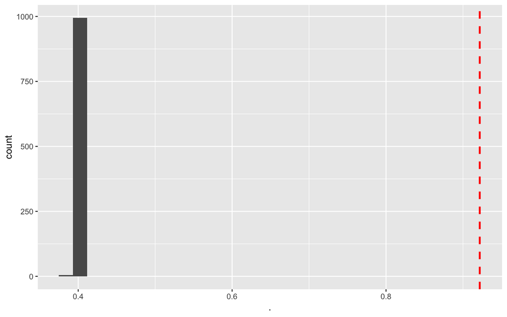

```r
CV_results$null_dist_train[,1]%>%
  as.data.frame(.)%>%
  ggplot(aes(x = `.`))+
  geom_histogram()+
  geom_vline(xintercept = results$train_r[1], linetype = "dashed", color = "red", size = 1)
```

### 1.1.7 Real vs permuted: Component 2, training

The bar plots indicate the null distribution of canonical correlations (i.e., 1000 x permuted data) whereas the red vertical line indicates the canonical correlation of the real data.

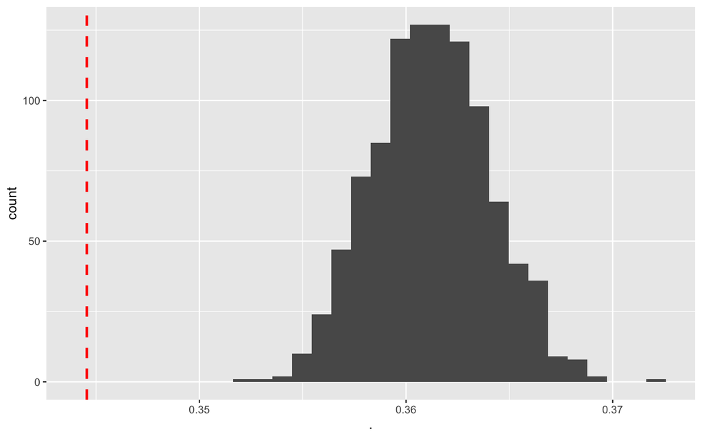

```r
CV_results$null_dist_train[,2]%>%
  as.data.frame(.)%>%
  ggplot(aes(x = `.`))+
  geom_histogram()+
  geom_vline(xintercept = results$train_r[2], linetype = "dashed", color = "red", size = 1)
```

### 1.1.8 Real vs permuted: Component 1, test

The bar plots indicate the null distribution of canonical correlations (i.e., 1000 x permuted data) whereas the red vertical line indicates the canonical correlation of the real data.

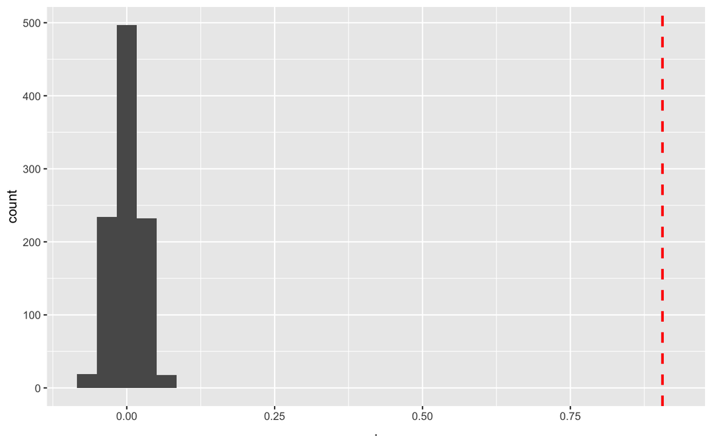

```r
CV_results$null_dist[,1]%>%
  as.data.frame(.)%>%
  ggplot(aes(x = `.`))+
  geom_histogram()+
  geom_vline(xintercept = results$test_r[1], linetype = "dashed", color = "red", size = 1)
```

### 1.1.9 Real vs permuted: Component 2, test

The bar plots indicate the null distribution of canonical correlations (i.e., 1000 x permuted data) whereas the red vertical line indicates the canonical correlation of the real data.

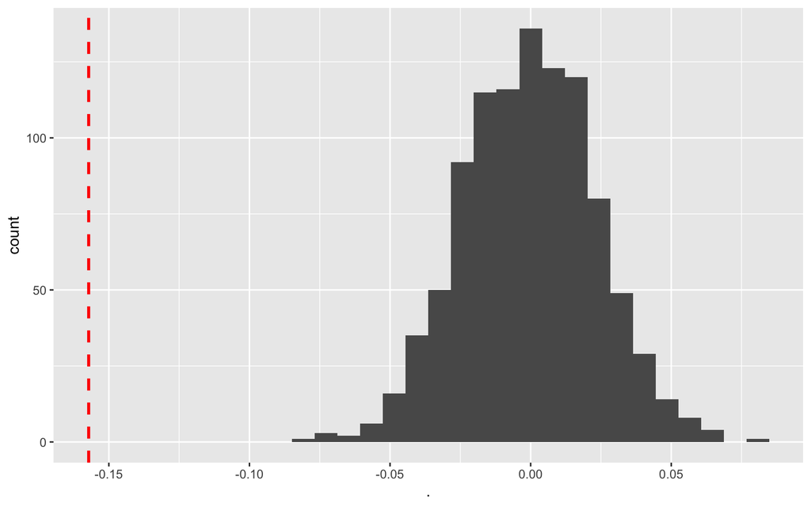

```r
CV_results$null_dist[,2]%>%
  as.data.frame(.)%>%
  ggplot(aes(x = `.`))+
  geom_histogram()+
  geom_vline(xintercept = results$test_r[2], linetype = "dashed", color = "red", size = 1)
```